# EDAV Final Project

# Agency’ Response Time Analysis

The top complaints happended on Jan 2015 mostly went into two agencies: HPD and DOT. We’d like to summarize their efficiecny of closing the top complaints that they are in charge of over the month.  
Especially, we want to look at the window between Jan 1st and Jan 15th, which is a week before/after the chaos day Jan 8th. And we will focus on the Manhattan borough since most of us lived in this neighborhood.  
We are curious if there is any pattern within the agency. For example, whether HPD’s response time to one type of complaint is affected by the other complaints? How’s their efficiecny in closing complaints that were created on the chaos day compared to that on the other days?

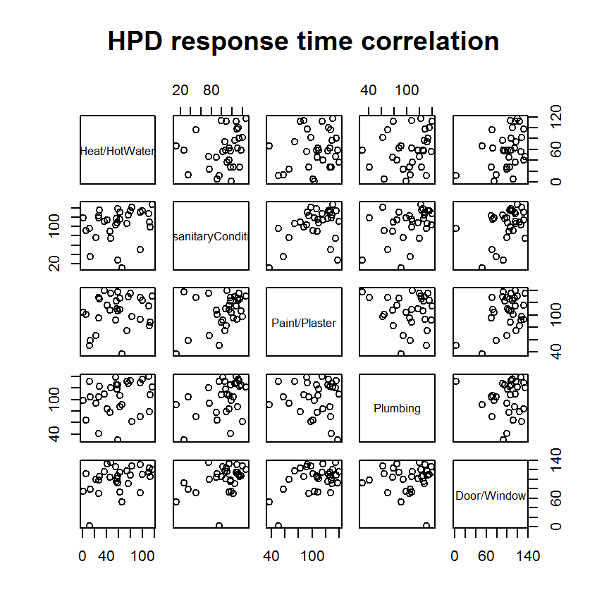

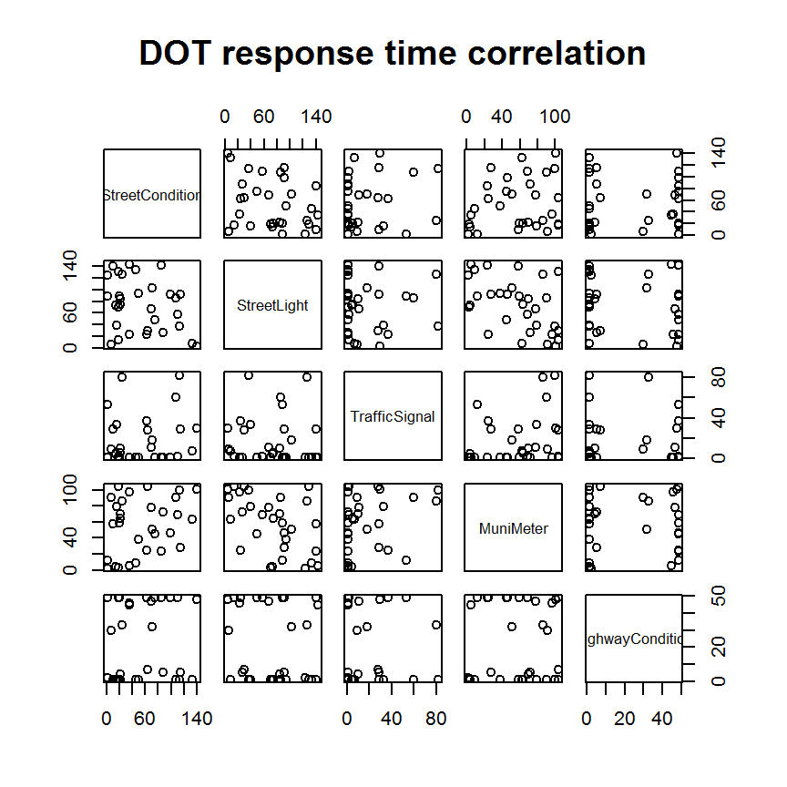

The pair correlations between types of complaints are very random for each agency.Then we move on to visualize the volumn of response time by complaint categories for two agencies.

[interactive chart not shown]

- HPD is relatively efficient in fixing the Heat/Hot Water complaints, which is necessary because it’s more urgent compared to other complaints during the winter days.
- This is also the case for complaints created on Jan 8th. If hover over Jan 8th, you will see that HPD took longer time closing Plumbing, Door/Window, Unsanitary Condition, Paint/Plaster issues than closing Heat/Hot Water complaint.

[interactive chart not shown]

- DOT’s response efficiency differs among types of complaints as well, while the contrast is more obvious. Highway Condition and Traffic Signal Condition are definitely more urgent than other cases and so they might be the priority things for DOT to work on.

From the visualization, we hardly found a pattern that could summarize the agency’s response time to different complaints over the week before/after Jan 8th, which is understandable as the urgency of complaints and other extragenous factors may affect the agency’s efficiency.

# References